# Why do we need parametric models in Survival Analysis?

Importance of maximum likelihood estimation (MLE)

Author

Eric Delmelle

Published

September 16, 2025

## Introduction

In survival analysis, we often start with the Kaplan-Meier estimator to understand our data. But you might wonder: **“Why do we need anything else? The Kaplan-Meier curve shows us exactly what happened in our study.”**

This document will show you why parametric models are incredibly useful, what we mean by “parameters,” and how we find the best parameter values using Maximum Likelihood Estimation (MLE).

## Part I: What Are Parametric Models and Why Do We Need Them?

### Understanding “Parameters” Through Simple Examples

Let’s start with a familiar concept. When we describe people’s heights, we might say: - “The average height is 170 cm” - “Most people are within 10 cm of that average”

These two numbers (**170** and **10**) are **parameters** - they summarize the entire distribution of heights with just two values.

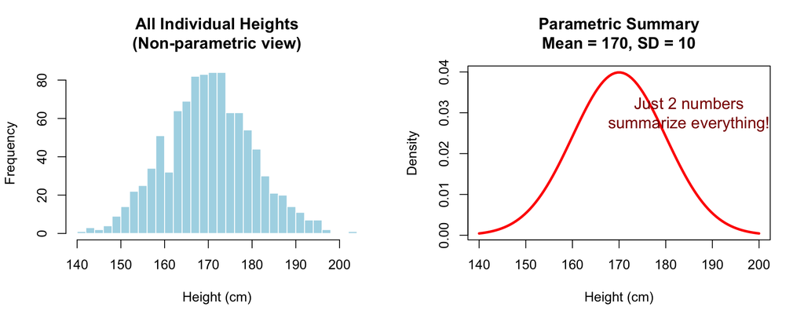

```r
# Load required packages
library(ggplot2)
library(survival)
library(flexsurv)

# Set seed for reproducibility
set.seed(123)

# Generate height data
heights <- rnorm(1000, mean = 170, sd = 10)

par(mfrow = c(1, 2))

# Plot 1: Show all the data (like Kaplan-Meier approach)
hist(heights, breaks = 30, main = "All Individual Heights\n(Non-parametric view)",
     xlab = "Height (cm)", col = "lightblue", border = "white")

# Plot 2: Show the parametric summary
x_vals <- seq(140, 200, length.out = 100)
normal_curve <- dnorm(x_vals, mean = 170, sd = 10)
plot(x_vals, normal_curve, type = "l", lwd = 3, col = "red",
     main = "Parametric Summary\nMean = 170, SD = 10",
     xlab = "Height (cm)", ylab = "Density")
text(185, 0.03, "Just 2 numbers\nsummarize everything!", col = "darkred", cex = 1.2)
```

**Key insight**: Instead of listing 1000 individual heights, we can describe the entire distribution with just 2 parameters!

### The Same Idea Applied to Survival Data

In survival analysis, this same principle applies. Instead of describing every individual survival time, we can use parameters to capture the essential patterns.

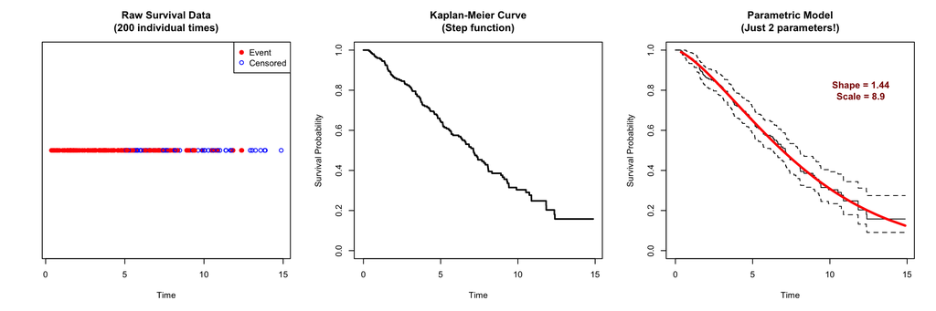

```r
# Simulate survival data
set.seed(456)
n <- 200

# Generate Weibull survival times with known parameters
shape_param <- 1.5  # This controls if risk increases/decreases over time
scale_param <- 10   # This controls the "time scale"
survival_times <- rweibull(n, shape = shape_param, scale = scale_param)

# Add some censoring
cens_times <- runif(n, min = 5, max = 15)
observed_times <- pmin(survival_times, cens_times)
events <- as.numeric(survival_times <= cens_times)

# Create survival object
surv_obj <- Surv(observed_times, events)

par(mfrow = c(1, 3))

# Plot 1: Raw data (like showing all individual heights)
plot(observed_times, rep(1, n), pch = ifelse(events == 1, 19, 1),
     main = "Raw Survival Data\n(200 individual times)",
     xlab = "Time", ylab = "", yaxt = "n",
     col = ifelse(events == 1, "red", "blue"))
legend("topright", c("Event", "Censored"), pch = c(19, 1), col = c("red", "blue"))

# Plot 2: Kaplan-Meier (step function)
km_fit <- survfit(surv_obj ~ 1)
plot(km_fit, conf.int = FALSE, main = "Kaplan-Meier Curve\n(Step function)",
     xlab = "Time", ylab = "Survival Probability", lwd = 2)

# Plot 3: Parametric model (smooth curve)
weibull_fit <- flexsurvreg(surv_obj ~ 1, dist = "weibull")
plot(weibull_fit, ci = FALSE, col = "red", lwd = 3,
     main = "Parametric Model\n(Just 2 parameters!)",
     xlab = "Time", ylab = "Survival Probability")

# Add parameter values
shape_est <- weibull_fit$res["shape", "est"]
scale_est <- weibull_fit$res["scale", "est"]
text(12, 0.8, paste0("Shape = ", round(shape_est, 2), "\nScale = ", round(scale_est, 1)),
     col = "darkred", cex = 1.1, font = 2)
```

**What we see**: The raw data shows 200 individual survival times. The Kaplan-Meier gives us a step function. The parametric model summarizes everything with just 2 numbers!

### Why Are Parametric Models So Useful?

Now that we understand what parameters are, let’s see why parametric models are incredibly powerful:

#### 1. **Compact Summarization**

Instead of a complex jagged curve, you get interpretable numbers:

```r
cat("Weibull Parameters from our data:\n")
```

```
Weibull Parameters from our data:
```

```r
cat("Shape parameter:", round(shape_est, 2), "\n")
```

```
Shape parameter: 1.44
```

```r
cat("Scale parameter:", round(scale_est, 1), "\n\n")
```

```
Scale parameter: 8.9
```

```r
cat("What these mean:\n")
```

```
What these mean:
```

```r
if (shape_est > 1) {
  cat("• Shape > 1: Risk INCREASES over time\n")
} else if (shape_est < 1) {
  cat("• Shape < 1: Risk DECREASES over time\n")
} else {
  cat("• Shape = 1: Risk stays CONSTANT over time\n")
}
```

```
• Shape > 1: Risk INCREASES over time
```

```r
cat("• Scale:", round(scale_est, 1), "represents the characteristic survival time\n")
```

```
• Scale: 8.9 represents the characteristic survival time
```

#### 2. **Extrapolation Beyond Your Study**

This is huge for practical applications!

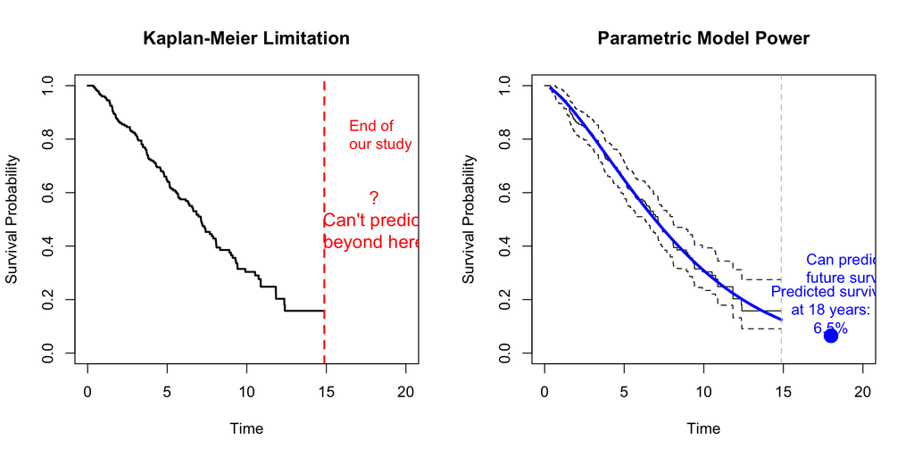

```r
par(mfrow = c(1, 2))

# Plot 1: What KM can tell us
max_followup <- max(observed_times)
plot(km_fit, conf.int = FALSE, xlim = c(0, 20),
     main = "Kaplan-Meier Limitation",
     xlab = "Time", ylab = "Survival Probability", lwd = 2)
abline(v = max_followup, lty = 2, col = "red", lwd = 2)
text(max_followup + 1, 0.8, "End of\nour study", pos = 4, col = "red")
text(18, 0.5, "?\nCan't predict\nbeyond here", col = "red", cex = 1.2)

# Plot 2: What parametric models can do
plot(weibull_fit, ci = FALSE, col = "blue", lwd = 3, xlim = c(0, 20),
     main = "Parametric Model Power",
     xlab = "Time", ylab = "Survival Probability")
abline(v = max_followup, lty = 2, col = "gray", lwd = 1)
text(max_followup + 1, 0.3, "Can predict\nfuture survival!", pos = 4, col = "blue")

# Show a specific prediction
future_time <- 18
future_surv <- 1 - pweibull(future_time, shape = shape_est, scale = scale_est)
points(future_time, future_surv, pch = 19, col = "blue", cex = 2)
text(future_time, future_surv + 0.1, paste0("Predicted survival\nat ", future_time, " years:\n",
                                              round(future_surv * 100, 1), "%"),
     col = "blue", adj = 0.5)
```

#### 3. **Easy Group Comparisons**

Comparing treatments becomes much clearer:

```r
# Simulate two treatment groups with different parameters
set.seed(789)

# Treatment A: Shape = 1.2, Scale = 12 (slightly increasing risk)
group_a_times <- rweibull(100, shape = 1.2, scale = 12)
# Treatment B: Shape = 0.8, Scale = 10 (decreasing risk over time)
group_b_times <- rweibull(100, shape = 0.8, scale = 10)

cat("Comparing Treatments:\n\n")
```

```
Comparing Treatments:
```

```r
cat("Treatment A parameters: Shape = 1.2, Scale = 12\n")
```

```
Treatment A parameters: Shape = 1.2, Scale = 12
```

```r
cat("→ Interpretation: Risk INCREASES over time, longer survival scale\n\n")
```

```
→ Interpretation: Risk INCREASES over time, longer survival scale
```

```r
cat("Treatment B parameters: Shape = 0.8, Scale = 10\n")
```

```
Treatment B parameters: Shape = 0.8, Scale = 10
```

```r
cat("→ Interpretation: Risk DECREASES over time, shorter survival scale\n\n")
```

```
→ Interpretation: Risk DECREASES over time, shorter survival scale
```

```r
cat("Conclusion: Treatment A may be better for long-term survival,\n")
```

```
Conclusion: Treatment A may be better for long-term survival,
```

```r
cat("but Treatment B shows improving outcomes for survivors.\n")
```

```
but Treatment B shows improving outcomes for survivors.
```

**This is much clearer than trying to compare two jagged Kaplan-Meier curves!**

## Part II: How Do We Find the Best Parameters? Enter Maximum Likelihood Estimation

Now that we understand WHY parametric models are useful, the next question is: **“How do we find the best parameter values for our data?”**

This is where **Maximum Likelihood Estimation (MLE)** comes in.

### What is Maximum Likelihood Estimation?

MLE asks a simple but powerful question:

> **“Given the data we observed, what parameter values would make this data most likely to occur?”**

Think of it like detective work: - You observe some evidence (your survival data) - You ask: “What underlying truth (parameters) would most likely produce this evidence?”

### A Simple Example: Coin Flipping

Before jumping to survival analysis, let’s understand MLE with coin flips:

```r
# Imagine we flip a coin 10 times and get 7 heads
heads <- 7
total_flips <- 10

cat("We observed:", heads, "heads out of", total_flips, "flips\n\n")
```

```
We observed: 7 heads out of 10 flips
```

```r
# What's the MLE estimate of the probability of heads?
mle_prob <- heads / total_flips
cat("MLE estimate: Probability of heads =", mle_prob, "\n\n")
```

```
MLE estimate: Probability of heads = 0.7
```

```r
cat("Why this makes sense:\n")
```

```
Why this makes sense:
```

```r
cat("• If p = 0.7, getting 7 heads out of 10 is quite likely\n")
```

```
• If p = 0.7, getting 7 heads out of 10 is quite likely
```

```r
cat("• If p = 0.3, getting 7 heads out of 10 is quite unlikely\n")
```

```
• If p = 0.3, getting 7 heads out of 10 is quite unlikely
```

```r
cat("• MLE picks p = 0.7 because it makes our data most probable\n")
```

```
• MLE picks p = 0.7 because it makes our data most probable
```

### Applying MLE to Survival Data

The same principle applies to survival data, but it’s more complex because: - We have censored observations (incomplete data) - We need to find multiple parameters simultaneously - The math is more complicated

Here’s how it works conceptually:

```r
cat("MLE for Survival Data:\n\n")
```

```
MLE for Survival Data:
```

```r
cat("1. Choose a distribution (e.g., Weibull)\n")
```

```
1. Choose a distribution (e.g., Weibull)
```

```r
cat("2. Try different parameter values\n")
```

```
2. Try different parameter values
```

```r
cat("3. For each combination, ask: 'How likely is our observed data?'\n")
```

```
3. For each combination, ask: 'How likely is our observed data?'
```

```r
cat("4. Pick the parameters that make our data MOST likely\n\n")
```

```
4. Pick the parameters that make our data MOST likely
```

```r
cat("Example with our data:\n")
```

```
Example with our data:
```

```r
cat("• True parameters used to generate data: Shape =", shape_param, ", Scale =", scale_param, "\n")
```

```
• True parameters used to generate data: Shape = 1.5 , Scale = 10
```

```r
cat("• MLE estimates from the data: Shape =", round(shape_est, 2), ", Scale =", round(scale_est, 1), "\n")
```

```
• MLE estimates from the data: Shape = 1.44 , Scale = 8.9
```

```r
cat("• Pretty close! MLE worked well.\n")
```

```
• Pretty close! MLE worked well.
```

### Why MLE is Powerful

1. **Principled approach**: Not guessing, but finding the most probable explanation
2. **Works with complex data**: Handles censoring, multiple parameters, etc.
3. **Optimal properties**: Under certain conditions, MLE gives the best possible estimates
4. **Widely applicable**: Used in almost all modern statistical methods

## Part III: Putting It All Together - Parametric Survival Analysis

### The Complete Workflow

Here’s how parametric survival analysis works in practice:

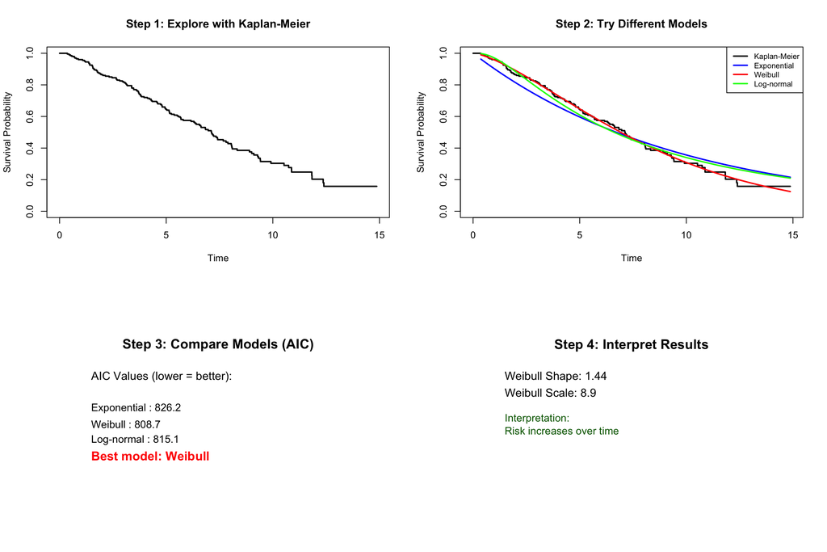

```r
# Step 1: Look at your data with Kaplan-Meier
par(mfrow = c(2, 2))

plot(km_fit, conf.int = FALSE, main = "Step 1: Explore with Kaplan-Meier",
     xlab = "Time", ylab = "Survival Probability", lwd = 2)

# Step 2: Fit multiple parametric models using MLE
exponential_fit <- flexsurvreg(surv_obj ~ 1, dist = "exponential")
lognormal_fit <- flexsurvreg(surv_obj ~ 1, dist = "lognormal")

# Step 3: Compare models
plot(km_fit, conf.int = FALSE, main = "Step 2: Try Different Models",
     xlab = "Time", ylab = "Survival Probability", lwd = 2, col = "black")
lines(exponential_fit, col = "blue", lwd = 2, ci = FALSE)
lines(weibull_fit, col = "red", lwd = 2, ci = FALSE)
lines(lognormal_fit, col = "green", lwd = 2, ci = FALSE)
legend("topright", c("Kaplan-Meier", "Exponential", "Weibull", "Log-normal"),
       col = c("black", "blue", "red", "green"), lwd = 2, cex = 0.8)

# Step 4: Compare model fit using AIC
models <- list("Exponential" = exponential_fit,
               "Weibull" = weibull_fit,
               "Log-normal" = lognormal_fit)
aic_values <- sapply(models, AIC)

plot.new()
text(0.5, 0.9, "Step 3: Compare Models (AIC)", cex = 1.4, font = 2, adj = 0.5)
text(0.1, 0.7, "AIC Values (lower = better):", cex = 1.2, adj = 0)
for(i in 1:length(aic_values)) {
  text(0.1, 0.6 - i*0.1, paste(names(aic_values)[i], ":", round(aic_values[i], 1)),
       cex = 1.1, adj = 0)
}
best_model <- names(aic_values)[which.min(aic_values)]
text(0.1, 0.2, paste("Best model:", best_model), cex = 1.3, adj = 0, col = "red", font = 2)

# Step 5: Interpret the best model
plot.new()
text(0.5, 0.9, "Step 4: Interpret Results", cex = 1.4, font = 2, adj = 0.5)
if(best_model == "Weibull") {
  text(0.1, 0.7, paste("Weibull Shape:", round(shape_est, 2)), cex = 1.2, adj = 0)
  text(0.1, 0.6, paste("Weibull Scale:", round(scale_est, 1)), cex = 1.2, adj = 0)
  if(shape_est > 1) {
    text(0.1, 0.4, "Interpretation:\nRisk increases over time", cex = 1.1, adj = 0, col = "darkgreen")
  } else {
    text(0.1, 0.4, "Interpretation:\nRisk decreases over time", cex = 1.1, adj = 0, col = "darkgreen")
  }
}
```

### Practical Applications

These methods are used daily in:

**Medical Research**: - Comparing treatment effectiveness - Predicting long-term survival rates - Planning clinical trials

**Engineering**: - Equipment reliability analysis  
- Maintenance scheduling - Quality control

**Business**: - Customer retention modeling - Employee turnover analysis - Product lifecycle management

## Key Takeaways

### What You Should Remember

1. **Parameters are powerful**: A few numbers can summarize complex patterns
2. **Parametric models extend Kaplan-Meier**: They don’t replace it, but add prediction and comparison capabilities
3. **MLE finds the best parameters**: It’s not guessing - it’s finding the most probable explanation for your data
4. **The workflow is systematic**: Explore → Fit → Compare → Validate → Interpret

### When to Use Each Approach

**Use Kaplan-Meier when**: - Exploring your data for the first time - No assumptions about underlying distributions - Describing what happened in your specific study

**Use parametric models when**: - You need to predict beyond your observation period - You want to compare groups quantitatively - You need smooth mathematical functions for further analysis - You’re building more complex models

### The Bottom Line

Parametric survival models and MLE give you powerful tools to: - **Summarize** complex survival patterns with interpretable parameters - **Predict** future outcomes beyond your study period  
- **Compare** treatments or groups quantitatively - **Build** more sophisticated models for regression analysis

These aren’t just academic concepts - they’re practical tools used every day in medicine, engineering, and business to make better decisions based on survival data.

## Further Reading

For deeper understanding: - Collett, D. (2015). *Modelling Survival Data in Medical Research* - Klein, J. P., & Moeschberger, M. L. (2003). *Survival Analysis: Techniques for Censored and Truncated Data*

*Remember: Every expert was once a beginner. Master these fundamentals, and you’ll have a solid foundation for advanced statistical modeling.*

[← Return to Course Materials](https://bsta-150.github.io/course/)